# Classification: trees and random forests

# Classification tree recap

Divide the feature space up into regions by making successive splits on the data and then within each region predict the most commonly occuring class.

**Advantages**

- Easy to interpret.
- Similar to human decision making.
- Do well with non-linear problems.
- Fast and scalable.

**Disadvantages**

Trees have high variance and are unstable.

- Single trees may overfit the training data.
- Small changes in the data will have big changes on the tree.

# Random forests

**Differences**

- Instead of growing a single tree, grow many trees.
- For each tree withhold approx. 1/3 of the data as a test set (bagging).
- For each split consider only some of the predictors (approx. $\sqrt{p}$) which decorrelates the trees by introducing variance.
- Predictions are made using a majority vote strategy (or sometimes averaged probabilities).

**Advantages**

- Built-in test set.
- Built-in measures of variable importance.
- More stable predictions.

# Out-of-bag (OOB) error

For each tree we have dataset of N randomly selected observations. On average approx. 1/3 of the data is unused.

The out-of-bag, or out-of-sample, error is the misclassification rate when we fit the data to the trees for which it was withheld.

This error is robust, there is no need for cross-validation.

OOB error can be calculated for each tree as you go, so you can find when adding additional trees no longer improves error.

# Variable importance

For a single classification tree, any predictor that is used may be important.

**Mean decrease in accuracy**

Since random forests contains many trees we can measure the the classification error for the OOB data and after permuting each predictor variable. The difference between the two are then averaged over all trees, and normalized by the standard deviation of the differences.

**Mean decrease in Gini**

The total decrease in node impurities (Gini) from splitting on the variable, averaged over all trees.

# `randomForest` package

```r
# install.packages("randomForest")
library(randomForest)

rf_fit <- randomForest(Group ~ X1 + X2,
                       data = train_data,
                       xtest = test_data[,c("X1", "X2")],
                       ytest = test_data$Group,
                       ntree = 1000,
                       importance = TRUE)
```

# Two-dimensional example

```
##
## Call:
##  randomForest(formula = Group ~ X1 + X2, data = train_data, xtest = test_data[,      c("X1", "X2")], ytest = test_data$Group, ntree = 1000, importance = TRUE)
##                Type of random forest: classification
##                      Number of trees: 1000
## No. of variables tried at each split: 1
##
##         OOB estimate of  error rate: 5.8%
## Confusion matrix:
##        Orange Blue class.error
## Orange    283   14  0.04713805
## Blue       15  188  0.07389163
##                 Test set error rate: 4.6%
## Confusion matrix:
##        Orange Blue class.error
## Orange    302   13  0.04126984
## Blue       10  175  0.05405405
```

# Misclassification rates

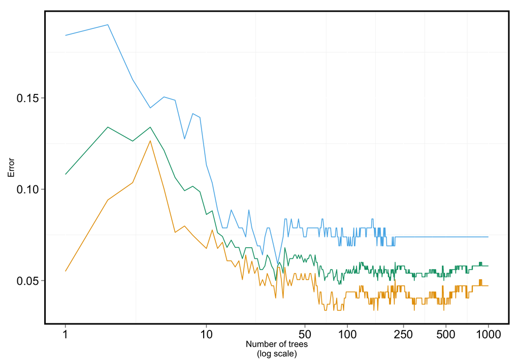

# Variable importance

```
##      Orange      Blue MeanDecreaseAccuracy MeanDecreaseGini
## X1 158.7368 170.96289             200.9958        159.77946
## X2 101.4301  96.22541             130.1410         80.59503
```

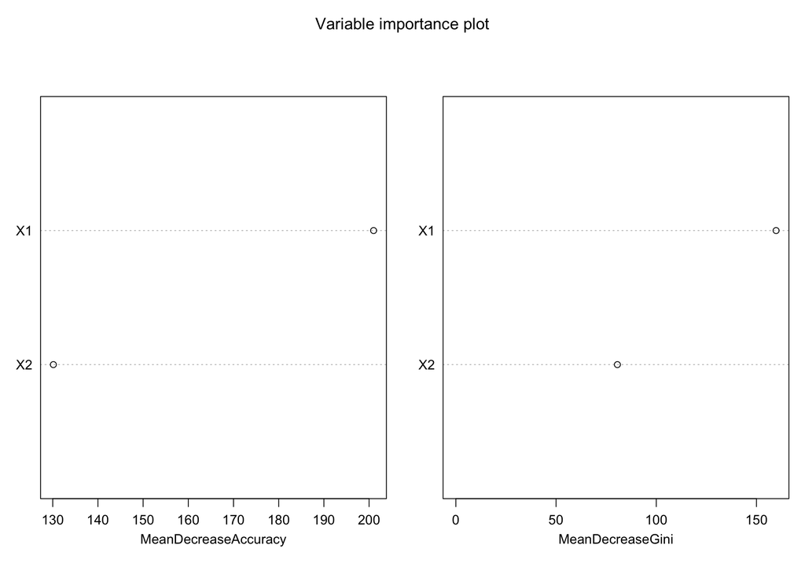

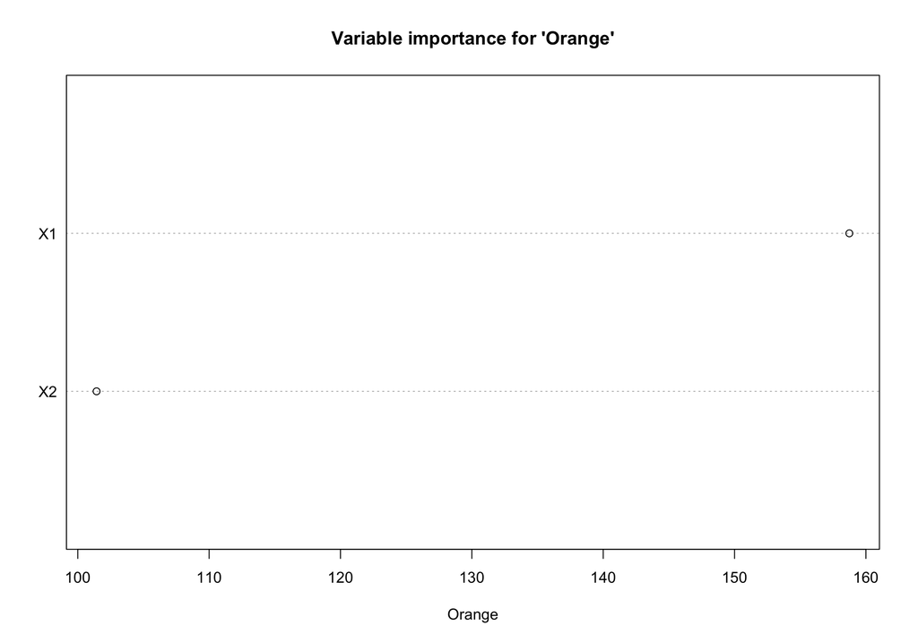

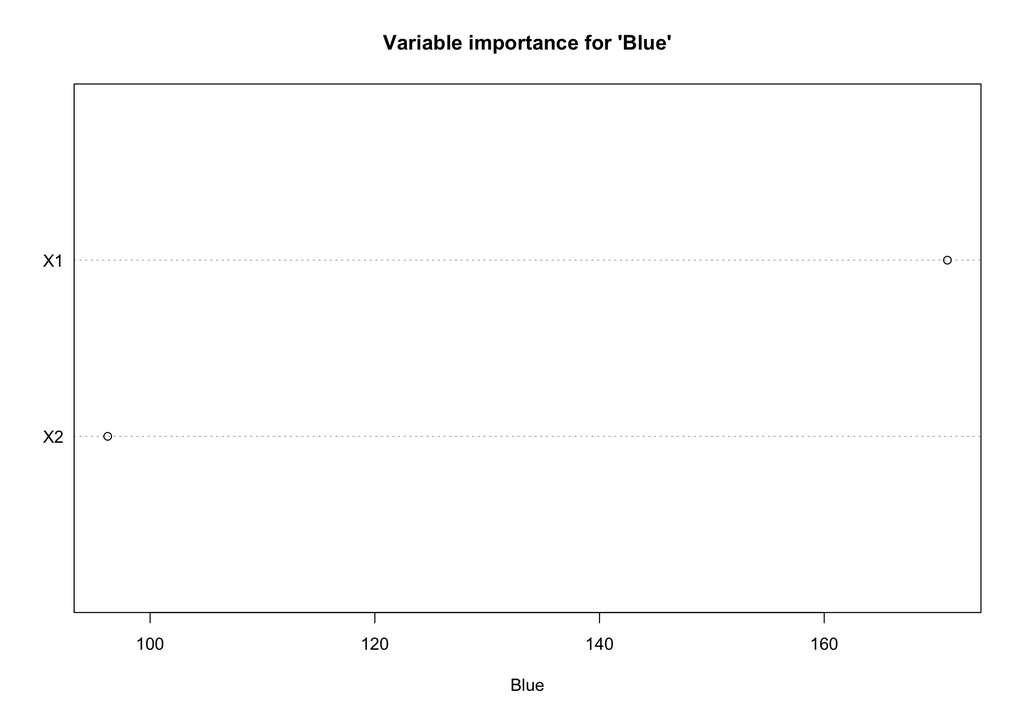

# Summary

# Additional topics

**Extremely randomized forests** - Geurts, P., Ernst, D., & Wehenkel, L. (2006). Extremely randomized trees. Machine Learning, 63(1), 3–42. doi:10.1007/s10994-006-6226-1

- available in the `extraTrees` package

**Gradient boosting machines** - Friedman, J. H. (1999). Greedy Function Approximation: A Gradient Boosting Machine.

- available in the `gbm` package

# Next month

Thursday, May 7, 2015 7:00 PM

Barracuda Networks 317 Maynard St, Ann Arbor, MI

**R markdown: A tool for code sharing, reproducibility, and more!** by Marian Schmidt

and

**Support Vector Machines and their implementation in R** by Michelle Berry